# Assignment 3: Verify the Claim: Rise of poverty rates in Philadelphia Neighbourhoods

- Show All Code
- Hide All Code
- View Source

Author

Lauryn Chan

Published

September 14, 2026

# Part 1 — Reconstruct

The WHYY article claims that poverty has risen from 2006-10 to 2013-17 based on the ACS five-year estimate. They have also quoted several neighbourhoods and calculated corresponding figures to prove their claim.

To verify their claims, I will be pulling the exact data from tidycensus to reconstruct (hopefully) similar figures and verify their statistical validity:

- **Years and survey**: ACS5 for 2010 and 2017
  - The two periods do not overlap as there is a gap between 2010 (the end of the first survey) and 2013 (the start of the second survey). This will avoid error generated from comparing the same information twice and does not display the full change in characteristic between the 2 years.
- **Variable code**: B07012_001, B07012_002
  - Based on the article that mentions “poverty rate” with margins of error, we need to compute poverty rate from the number of people below the poverty line (_002) divided by total population (_001).
- **Level**: Tract
  - To roughly equate tracts to neighbourhoods that were compared in the article

**Assumptions**: For simplistic reasons, I assume 1 tract will correspond to 1 neighbourhood referred to in the article. The corresponding tract number is found by inputting a random address in a residential area of the referenced neighbourhood into the [Census Geocoder](https://geocoding.geo.census.gov/geocoder/).

### 1a. Pulling data

Pulling data from the census, we manipulate the data to get a wide dataframe with columns:

1. **GEOID**
2. **Name**: of census tract
3. **below_povertyE**: the estimated number of people below the poverty line
4. **below_povertyM**: the margin of error for below_povertyE
5. **totalE**: total estimated population
6. **totalM**: the margin of error for totalE
7. **period**: time period (either 2010 or 2017)

```r
my_state <- "PA"
my_county <- "Philadelphia"

get_poverty <- function(yr) {
  get_acs(
    geography = "tract",
    variables = c(below_poverty = "B07012_002", #this targets the people below the poverty line
                  total = "B07012_001"),
    state = my_state,
    county = my_county,
    year = yr,
    survey = "acs5",
    output = "wide"
  ) |>
    mutate(period = paste0(yr - 4, "_", yr))
}

# Fetch ACS data
poverty_change <- bind_rows(
  get_poverty(2010),
  get_poverty(2017)
) |>
  mutate(NAME = str_remove(NAME, ", Philadelphia County, Pennsylvania"))

poverty_change$period <- substr(poverty_change$period, 6, nchar(poverty_change$period))

glimpse(poverty_change)
```

```
Rows: 768
Columns: 7
$ GEOID          <chr> "42101007102", "42101007200", "42101007300", "421010074…
$ NAME           <chr> "Census Tract 71.02", "Census Tract 72", "Census Tract …
$ below_povertyE <dbl> 1653, 1667, 713, 1568, 628, 832, 695, 873, 837, 967, 16…
$ below_povertyM <dbl> 566, 492, 330, 517, 253, 271, 387, 433, 402, 369, 761, …
$ totalE         <dbl> 4953, 5164, 3045, 4461, 1636, 3868, 4468, 3568, 2268, 4…
$ totalM         <dbl> 759, 723, 401, 536, 282, 525, 626, 518, 407, 481, 1048,…
$ period         <chr> "2010", "2010", "2010", "2010", "2010", "2010", "2010",…
```

*Above: Long format dataframe of ACS5 poverty data from 2006-2010 and 2013-2017*

# Part 2 — Test

### 2a. Computing the poverty rate

- Poverty rate (*share_*) was calculated by dividing *below_povertyE* by *totalE*
- Margin of error for poverty rate (*share_moe*) was calculated using the *moe_prop()* function in R

```r
# compute poverty share & moe before creating wide dataframe
poverty_change <- poverty_change |>
  mutate(
    share     = below_povertyE / totalE,
    share_moe = moe_prop(below_povertyE, totalE,
                         below_povertyM, totalM)
  )

# wrangling to wide format to MASTER DATAFRAME
poverty_master <- poverty_change |>
  select(GEOID, NAME, period, share, share_moe) |>
  rename(moe = share_moe) |>
  pivot_wider(
    names_from = period,
    values_from = c(share, moe)
  )

glimpse(poverty_master)
```

```
Rows: 384
Columns: 6
$ GEOID      <chr> "42101007102", "42101007200", "42101007300", "42101007400",…
$ NAME       <chr> "Census Tract 71.02", "Census Tract 72", "Census Tract 73",…
$ share_2010 <dbl> 0.3337371, 0.3228118, 0.2341544, 0.3514907, 0.3838631, 0.21…
$ share_2017 <dbl> 0.3404876, 0.3367369, 0.2927126, 0.3331920, 0.4581894, 0.24…
$ moe_2010   <dbl> 0.10219139, 0.08387270, 0.10389486, 0.10792440, 0.13977531,…
$ moe_2017   <dbl> 0.10831883, 0.11024197, 0.14143280, 0.09269676, 0.09955591,…
```

*Above: Wide format dataframe of change in ACS5 poverty rate from 2006-2010 and 2013-2017*

### 2b. Coefficient of variation

Coefficient of variation (*cv*) (in percentage) = (*moe*/1.645)/*share* * 100, where 1.645 is the z-score for a 90% two-tailed confidence level.

```r
poverty_variation <- poverty_master |>
  mutate(
    cv_2010 = (moe_2010 / 1.645)/share_2010 *100,
    cv_2017 = (moe_2017 / 1.645)/share_2017 *100,
  )

glimpse(poverty_variation)
```

```
Rows: 384
Columns: 8
$ GEOID      <chr> "42101007102", "42101007200", "42101007300", "42101007400",…
$ NAME       <chr> "Census Tract 71.02", "Census Tract 72", "Census Tract 73",…
$ share_2010 <dbl> 0.3337371, 0.3228118, 0.2341544, 0.3514907, 0.3838631, 0.21…
$ share_2017 <dbl> 0.3404876, 0.3367369, 0.2927126, 0.3331920, 0.4581894, 0.24…
$ moe_2010   <dbl> 0.10219139, 0.08387270, 0.10389486, 0.10792440, 0.13977531,…
$ moe_2017   <dbl> 0.10831883, 0.11024197, 0.14143280, 0.09269676, 0.09955591,…
$ cv_2010    <dbl> 18.61418, 15.79448, 26.97279, 18.66551, 22.13544, 17.99966,…
$ cv_2017    <dbl> 19.339123, 19.901709, 29.372634, 16.912353, 13.208581, 19.2…
```

*Above: Wide format dataframe of change in ACS5 poverty rate from 2006-2010 and 2013-2017*

### 2c. Reliability table

A reliability table was built to show the poverty share, moe, and cv for each census tract and the associated reliability of the data based on the coefficient of variation.

```r
reliability_table <- poverty_variation |>
  mutate(
    dot_2010 = case_when(
      cv_2010 < 12  ~ "🟢",
      cv_2010 <= 40 ~ "🟡",
      TRUE          ~ "🔴"
    ),
    dot_2017 = case_when(
      cv_2017 < 12  ~ "🟢",
      cv_2017 <= 40 ~ "🟡",
      TRUE          ~ "🔴"
    ),
    flag_2010 = case_when(
      cv_2010 < 12  ~ "Reliable",
      cv_2010 <= 40 ~ "Somewhat reliable",
      TRUE          ~ "Unreliable"
    ),
    flag_2017 = case_when(
      cv_2017 < 12  ~ "Reliable",
      cv_2017 <= 40 ~ "Somewhat reliable",
      TRUE          ~ "Unreliable"
    )
  )


# Make it look nice using gt package
reliability_table |>
  gt() |>
  fmt_percent(columns = c(share_2010, share_2017), decimals = 1) |>
  fmt_number(columns = c(moe_2010, moe_2017), decimals = 3) |>
  fmt_number(columns = c(cv_2010, cv_2017), decimals = 1) |>
  cols_label(
    dot_2010 = "",
    dot_2017 = "",
    NAME     = "County",
    share_2010 = "Poverty Share 2010",
    share_2017 = "Poverty Share 2017",
    moe_2010 = "MOE 2010",
    moe_2017 = "MOE 2017",
    cv_2010  = "CV 2010 (%)",
    cv_2017  = "CV 2017 (%)",
    flag_2010 = "Reliability 2010",
    flag_2017 = "Reliability 2017"
  ) |>
  cols_move(
    columns = dot_2010,
    after = flag_2010
  ) |>
  cols_move(
    columns = dot_2017,
    after = flag_2017
  ) |>
  cols_align(align = "center", columns = c(dot_2010, dot_2017)) |>
  tab_header(
    title    = "Population below 100% of the poverty level",
    subtitle = "Philadelphia tracts, ACS 5-year estimates"
  ) |>
  tab_source_note(
    "Reliability thresholds follow Jurjevich et al. (2018): CV < 12% reliable, 12–40% somewhat reliable, > 40% unreliable."
  )
```

Population below 100% of the poverty level

Philadelphia tracts, ACS 5-year estimates

| GEOID | County | Poverty Share 2010 | Poverty Share 2017 | MOE 2010 | MOE 2017 | CV 2010 (%) | CV 2017 (%) | Reliability 2010 |  | Reliability 2017 |  |
| --- | --- | --- | --- | --- | --- | --- | --- | --- | --- | --- | --- |
| 42101007102 | Census Tract 71.02 | 33.4% | 34.0% | 0.102 | 0.108 | 18.6 | 19.3 | Somewhat reliable | 🟡 | Somewhat reliable | 🟡 |
| 42101007200 | Census Tract 72 | 32.3% | 33.7% | 0.084 | 0.110 | 15.8 | 19.9 | Somewhat reliable | 🟡 | Somewhat reliable | 🟡 |
| 42101007300 | Census Tract 73 | 23.4% | 29.3% | 0.104 | 0.141 | 27.0 | 29.4 | Somewhat reliable | 🟡 | Somewhat reliable | 🟡 |
| 42101007400 | Census Tract 74 | 35.1% | 33.3% | 0.108 | 0.093 | 18.7 | 16.9 | Somewhat reliable | 🟡 | Somewhat reliable | 🟡 |
| 42101007700 | Census Tract 77 | 38.4% | 45.8% | 0.140 | 0.100 | 22.1 | 13.2 | Somewhat reliable | 🟡 | Somewhat reliable | 🟡 |
| 42101007800 | Census Tract 78 | 21.5% | 24.1% | 0.064 | 0.076 | 18.0 | 19.2 | Somewhat reliable | 🟡 | Somewhat reliable | 🟡 |
| 42101007900 | Census Tract 79 | 15.6% | 12.6% | 0.084 | 0.054 | 32.8 | 26.2 | Somewhat reliable | 🟡 | Somewhat reliable | 🟡 |
| 42101008000 | Census Tract 80 | 24.5% | 26.0% | 0.116 | 0.083 | 28.8 | 19.4 | Somewhat reliable | 🟡 | Somewhat reliable | 🟡 |
| 42101008101 | Census Tract 81.01 | 36.9% | 42.1% | 0.164 | 0.147 | 27.1 | 21.3 | Somewhat reliable | 🟡 | Somewhat reliable | 🟡 |
| 42101008102 | Census Tract 81.02 | 19.6% | 34.8% | 0.072 | 0.127 | 22.4 | 22.3 | Somewhat reliable | 🟡 | Somewhat reliable | 🟡 |
| 42101008200 | Census Tract 82 | 20.0% | 20.7% | 0.089 | 0.102 | 27.1 | 30.0 | Somewhat reliable | 🟡 | Somewhat reliable | 🟡 |
| 42101008301 | Census Tract 83.01 | 30.2% | 21.7% | 0.070 | 0.067 | 14.2 | 18.8 | Somewhat reliable | 🟡 | Somewhat reliable | 🟡 |
| 42101008302 | Census Tract 83.02 | 38.3% | 34.0% | 0.092 | 0.105 | 14.6 | 18.8 | Somewhat reliable | 🟡 | Somewhat reliable | 🟡 |
| 42101008400 | Census Tract 84 | 34.1% | 27.8% | 0.117 | 0.105 | 20.9 | 23.0 | Somewhat reliable | 🟡 | Somewhat reliable | 🟡 |
| 42101008500 | Census Tract 85 | 30.8% | 36.6% | 0.087 | 0.098 | 17.2 | 16.3 | Somewhat reliable | 🟡 | Somewhat reliable | 🟡 |
| 42101008601 | Census Tract 86.01 | 21.9% | 19.8% | 0.133 | 0.066 | 36.9 | 20.3 | Somewhat reliable | 🟡 | Somewhat reliable | 🟡 |
| 42101008602 | Census Tract 86.02 | 25.4% | 18.1% | 0.110 | 0.081 | 26.3 | 27.2 | Somewhat reliable | 🟡 | Somewhat reliable | 🟡 |
| 42101008701 | Census Tract 87.01 | 28.5% | 25.2% | 0.083 | 0.068 | 17.7 | 16.4 | Somewhat reliable | 🟡 | Somewhat reliable | 🟡 |
| 42101008702 | Census Tract 87.02 | 51.0% | 33.4% | 0.175 | 0.074 | 20.9 | 13.4 | Somewhat reliable | 🟡 | Somewhat reliable | 🟡 |
| 42101008801 | Census Tract 88.01 | 83.2% | 64.0% | 0.290 | 0.192 | 21.2 | 18.3 | Somewhat reliable | 🟡 | Somewhat reliable | 🟡 |
| 42101008802 | Census Tract 88.02 | 75.0% | 64.2% | 0.188 | 0.129 | 15.2 | 12.2 | Somewhat reliable | 🟡 | Somewhat reliable | 🟡 |
| 42101009000 | Census Tract 90 | 52.2% | 61.0% | 0.138 | 0.075 | 16.0 | 7.5 | Somewhat reliable | 🟡 | Reliable | 🟢 |
| 42101009100 | Census Tract 91 | 40.4% | 50.6% | 0.099 | 0.102 | 14.9 | 12.2 | Somewhat reliable | 🟡 | Somewhat reliable | 🟡 |
| 42101009200 | Census Tract 92 | 33.9% | 43.5% | 0.118 | 0.094 | 21.3 | 13.2 | Somewhat reliable | 🟡 | Somewhat reliable | 🟡 |
| 42101009300 | Census Tract 93 | 37.7% | 28.6% | 0.093 | 0.107 | 15.0 | 22.7 | Somewhat reliable | 🟡 | Somewhat reliable | 🟡 |
| 42101009400 | Census Tract 94 | 44.4% | 43.6% | 0.126 | 0.076 | 17.3 | 10.5 | Somewhat reliable | 🟡 | Reliable | 🟢 |
| 42101009500 | Census Tract 95 | 34.8% | 38.5% | 0.110 | 0.101 | 19.1 | 16.0 | Somewhat reliable | 🟡 | Somewhat reliable | 🟡 |
| 42101009600 | Census Tract 96 | 25.4% | 35.0% | 0.113 | 0.095 | 27.1 | 16.5 | Somewhat reliable | 🟡 | Somewhat reliable | 🟡 |
| 42101009801 | Census Tract 98.01 | 22.7% | 19.8% | 0.158 | 0.089 | 42.3 | 27.4 | Unreliable | 🔴 | Somewhat reliable | 🟡 |
| 42101009802 | Census Tract 98.02 | 15.2% | 19.3% | 0.092 | 0.093 | 37.0 | 29.2 | Somewhat reliable | 🟡 | Somewhat reliable | 🟡 |

[output cut: 354 more lines]

Reliability thresholds follow Jurjevich et al. (2018): CV < 12% reliable, 12–40% somewhat reliable, > 40% unreliable.

*Above: Reliability table of poverty share per tract, based on coefficient of variation*

### 2d. Computing poverty change, and associated margin of error

I will test whether the change is statistically distinguishable from zero at 90% confidence.

Reliability thresholds follow Jurjevich et al. (2018): CV < 12% reliable, 12–40% somewhat reliable, > 40% unreliable.

**However, some troubleshooting is done first:**

```r
poverty_tested <- poverty_master |>
  mutate(
    change   = `share_2017` - `share_2010`,
    se_2010  = `moe_2010` / 1.645,
    se_2017  = `moe_2017` / 1.645,
    se_diff  = sqrt(se_2010^2 + se_2017^2),
    moe_diff = se_diff * 1.645,
    z        = change / se_diff,
    significant = abs(z) > 1.645    #using z-score for 90% confidence (2 tails)
  )

#Removing NA values
tested_NA <- poverty_tested |>
  filter(change == "NaN")

head(tested_NA)
```

```
# A tibble: 6 × 13
  GEOID    NAME  share_2010 share_2017 moe_2010 moe_2017 change  se_2010 se_2017
  <chr>    <chr>      <dbl>      <dbl>    <dbl>    <dbl>  <dbl>    <dbl>   <dbl>
1 4210100… Cens…   NaN             NaN  NaN          NaN    NaN NaN          NaN
2 4210198… Cens…   NaN             NaN  NaN          NaN    NaN NaN          NaN
3 4210198… Cens…   NaN             NaN  NaN          NaN    NaN NaN          NaN
4 4210198… Cens…   NaN             NaN  NaN          NaN    NaN NaN          NaN
5 4210198… Cens…     0.0978        NaN    0.138      NaN    NaN   0.0837     NaN
6 4210198… Cens…   NaN             NaN  NaN          NaN    NaN NaN          NaN
# ℹ 4 more variables: se_diff <dbl>, moe_diff <dbl>, z <dbl>, significant <lgl>
```

*Above: Detected NA values from dataframe*

8 tracts displayed NA values for poverty shares for one/both surveys. To figure out what caused this, I input their GEOID into the [census website](https://data.census.gov/map/1400000US42101005000%2C42101980300%2C42101980400%2C42101980500%2C42101980600%2C42101980700%2C42101980800%2C42101980900) to check their location. We can see that these tracts are located in non-residential areas. For example,

- Tract 9804 covers the airport area
- Tract 9806 covers the parking lot in Stadium
- Tract 9808 covers Overbrooke Park

Therefore we will remove them from the dataset because it is irrelevant to poverty analysis of residents in Philadelphia.

**For the remaining rows, we determine the number of significant changes:**

```r
poverty_tested <- poverty_tested |>
    filter(change != "NaN")

poverty_tested |>
  count(significant)
```

```
# A tibble: 2 × 2
  significant     n
  <lgl>       <int>
1 FALSE         313
2 TRUE           63
```

*Above: Count of tracts with a statistically significant change in poverty rate from 2010 to 2017*

Only 63 out of 376 total tracts show a statistically detectable change across the 2 ACS surveys, which could mean that the article’s claims are not very valid.

### 2e. Visualising the change in poverty rates: A bar chart of the 15 most reliable tracts

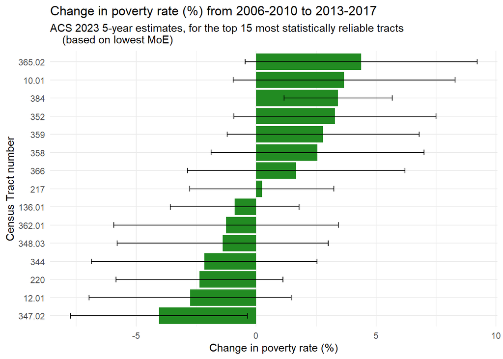

```r
poverty_tested |>
  arrange(desc(moe_diff)) |>
  slice_tail(n = 15) |>                                        # Of the 15 values with LOWEST moe
  mutate(NAME = str_remove(NAME, "Census Tract "),
         change = change * 100,
         moe_diff = moe_diff * 100) |>
  ggplot(aes(x = reorder(NAME, change), y = change)) +
  geom_col(fill = "forestgreen") +
  geom_errorbar(aes(ymin = change - moe_diff, ymax = change + moe_diff), width = 0.3) +
  coord_flip() +
  theme_minimal() +
  scale_y_continuous(labels = scales::comma) +
  labs(
    title = "Change in poverty rate (%) from 2006-2010 to 2013-2017",
    subtitle = "ACS 2023 5-year estimates, for the top 15 most statistically reliable tracts
    (based on lowest MoE)",
    x = "Census Tract number",
    y = "Change in poverty rate (%)"
  )
```

*Above: Bar chart (with error bars) of poverty change in top 15 most reliable tracts*

# Part 3 — Adjudicate

We will compute the article’s city-wide and neighbourhood-specific claims to check its accuracy. We will also test its statistical significance of the result we computed.

### 3a. Supported

**NoteClaim 1**

“Philadelphia has a 26% poverty rate from 2013-2017.”

```r
# Calculate overall mean, moe, cv
poverty_tested |>
  summarise(
    number_of_tracts   = n(),
    mean_share = mean(share_2017),
    mean_moe   = (moe_sum(moe = moe_2017, estimate = share_2017) / n()) ,
    mean_cv = (mean_moe / 1.645)/mean_share
  )
```

```
# A tibble: 1 × 4
  number_of_tracts mean_share mean_moe mean_cv
             <int>      <dbl>    <dbl>   <dbl>
1              376      0.260  0.00745  0.0174
```

The mean poverty rate across all tracts is indeed 26%, with a low coefficient of variation (cv) of 1.74%, indicating high reliability.

### 3b. Not supported

**NoteClaim 2**

“The neighborhood of Eastwick in Southwest Philadelphia, near Philadelphia International Airport, showed the greatest poverty-rate increase of any community, rocketing from 12 percent during 2006-10 to 26 percent in the newest survey. That means that even after the recession ended, around a decade ago, conditions in Eastwick have gotten much worse than during the depth of the downturn.”

Using the Census Geocoder, the approximate tract of Eastwick is Census Tract 61

```r
# Calculate overall mean, moe, cv
poverty_tested |>
  filter(NAME == "Census Tract 61") |>
  select(GEOID, NAME, share_2017, share_2010, change, moe_diff, significant) |>
  mutate(cv = (moe_diff / 1.645)/change)
```

```
# A tibble: 1 × 8
  GEOID       NAME       share_2017 share_2010 change moe_diff significant    cv
  <chr>       <chr>           <dbl>      <dbl>  <dbl>    <dbl> <lgl>       <dbl>
1 42101006100 Census Tr…      0.246      0.133  0.113    0.143 FALSE       0.765
```

Figures quoted are comparable enough, increasing from 13% during 2006-10 to 25% in the newest survey. However, the coefficient of variation is 76% which is very high, suggesting that there is no statistically detectable change from 2010 to 2017.

### 3c. Cannot be determined

**NoteClaim 3**

“Fairhill in North Philadelphia registered a stunning 61 percent poverty rate.”

Fairhill: Census Tract 176.02.

```r
# Calculate overall mean, moe, cv
poverty_tested |>
  filter(NAME == "Census Tract 176.02") |>
  select(GEOID, NAME, share_2017, moe_2017) |>
  mutate(cv = (moe_2017 / 1.645)/share_2017)
```

```
# A tibble: 1 × 5
  GEOID       NAME                share_2017 moe_2017    cv
  <chr>       <chr>                    <dbl>    <dbl> <dbl>
1 42101017602 Census Tract 176.02      0.614    0.122 0.121
```

Based on Jurjevich et al. (2018), the calculated poverty rate for Fairhill is accurate (61%), but only somewhat reliable based on the coefficient of variation of 12%. We will need to do more testing based on the surrounding tracts to create a more accurate profile of Fairhill.

**NoteClaim 4**

“White poverty throughout much of the city skyrocketed, led by the Northeast neighborhood of Holmesburg, which went from a 2 percent poverty rate to 19 percent.”

Holmesburg: Census Tract 326

```r
# Calculate overall mean, moe, cv
poverty_tested |>
  filter(NAME %in% c("Census Tract 326", "Census Tract 315.01")) |>
  select(GEOID, NAME, share_2017, share_2010, change, moe_diff, z, significant) |>
  mutate(cv = ((moe_diff / 1.645) / change) * 100) |>
  select(NAME, share_2017, share_2010, change, significant, cv)
```

```
# A tibble: 2 × 6
  NAME                share_2017 share_2010 change significant    cv
  <chr>                    <dbl>      <dbl>  <dbl> <lgl>       <dbl>
1 Census Tract 315.01      0.166     0.0730 0.0928 FALSE        63.1
2 Census Tract 326         0.225     0.167  0.0574 FALSE       125.
```

- As seen from the results, equating Holmesburg to Tract 326 yielded very different values with a poverty rate of 17% in 2010, unlike the 2% rate that the article claimed.
- Exploration of values in adjacent tracts showed high variability within Holmesburg - for example, the adjacent Tract 315.01 has a vastly different poverty rate of 7% in 2010.
- While it is true that poverty rates “skyrocketed” to 17% and 22% across the two tracts, the significance is false. The article’s statement is not only statistically invalid, but also does not account for high variability within Holmesburg. The surrounding census tracts should be investigated as well.
- Furthermore, the term “white poverty” will need to be verified by investigating the ethnic makeup of Holmesburg, to truly verify whether it is a mainly white population that is undergoing skyrocketing poverty.

# Part 4 — Rewrite

Philadelphia’s poverty rate was ~26% in the 2013–2017 ACS, but neighbourhood-level comparisons are less straightforward than the original article suggests.

- Fairhill’s estimated poverty rate was 61%, although further analysis of surrounding census tracts is needed to determine how well this figure represents the wider neighbourhood.
- Eastwick’s poverty rate increased from about 13% in 2006–2010 to 25% in 2013–2017, but the large uncertainty around this change means that it is not statistically detectable.
- Similarly, poverty increased substantially across the census tracts examined in Holmesburg, but the data does not establish that the change was statistically significant, nor that it was concentrated among white residents.

These results show substantial poverty across Philadelphia, while also highlighting the importance of accounting for uncertainty and variation between census tracts when interpreting neighbourhood-level changes.